# Homework

Your Name

11 Juli 2021

# A Shoddy Survey Company

## Prologue

Finally. The survey company you hired (Survey Company International) just mailed you the raw data.<sup>[1]</sup>

You came a long way. You secured funding for your research project/thesis, presented it to your supervisors, did a systematic review, wrote the theory section, and designed the questionnaire.

Now, the exciting part begins.

You unzip the folder, and there it is, the precious file you need so desperately…

[figure not shown]

… In `.xlsx`. “Huh?” You asked explicitly for a more robust file type.

But, alas, maybe they misread the e-mail, and at least it’s not stored in [`.xls`](https://www.bbc.com/news/technology-54423988).

“Thanks to R’s extensive importing capabilities, that’s no issue at all,” you say to yourself.

“It’s not like they messed up data collection; it’s just stored as .xlsx”.

You click on the file.

“Nevermind.”

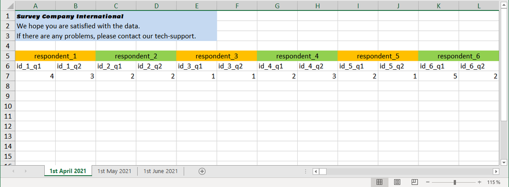

<sup>[1] Name made up.</sup>

## Some notes on the data

- $N = 500$
- This is not an actual data set. It was simulated with R.
- It’s a “panel” survey consisting of three waves in April, May, and June.
- “id_x” is the respondent identfier.
- The survey consists of two questions named q1 and q2.

# Tasks

1. Read-in the data.
2. Tidy the data.
3. For each date, calculate the mean of q1 and q2.
4. Manually generate a frequency table for q1 and q2, grouped by date.

If you put out your document to `html`, explore `DT::datatable()` for some interactivity!

You do not need to manipulate the Excel file manually to complete these tasks.

## Hints

Look up `?rio::import_list` and the `here` package. I normalized the directory in the `knitr` setup of this `.Rmd` file such that relative file paths from the project root should work (but this depends on the OS).

You will likely practice a key skill for your career as empirical researcher/ data scientist: googling. That’s normal!